# Risk Factor Analysis

## Outcome Variable

**Outcome Variable:** ever_co

## Predictor Variables

**Intervention Variable:** birthlen

**Adjustment Set:**

unadjusted

## Stratifying Variables

The analysis was stratified on these variable(s):

- agecat
- studyid
- country

## Data Summary

| agecat | studyid | country | birthlen | ever_co | n_cell | n |
| --- | --- | --- | --- | --- | --- | --- |
| 0-24 months | CMC-V-BCS-2002 | INDIA | >=50 cm | 0 | 15 | 106 |
| 0-24 months | CMC-V-BCS-2002 | INDIA | >=50 cm | 1 | 1 | 106 |
| 0-24 months | CMC-V-BCS-2002 | INDIA | <48 cm | 0 | 37 | 106 |
| 0-24 months | CMC-V-BCS-2002 | INDIA | <48 cm | 1 | 13 | 106 |
| 0-24 months | CMC-V-BCS-2002 | INDIA | [48-50) cm | 0 | 36 | 106 |
| 0-24 months | CMC-V-BCS-2002 | INDIA | [48-50) cm | 1 | 4 | 106 |
| 0-24 months | CMIN | BANGLADESH | >=50 cm | 0 | 2 | 20 |
| 0-24 months | CMIN | BANGLADESH | >=50 cm | 1 | 0 | 20 |
| 0-24 months | CMIN | BANGLADESH | <48 cm | 0 | 7 | 20 |
| 0-24 months | CMIN | BANGLADESH | <48 cm | 1 | 3 | 20 |
| 0-24 months | CMIN | BANGLADESH | [48-50) cm | 0 | 7 | 20 |
| 0-24 months | CMIN | BANGLADESH | [48-50) cm | 1 | 1 | 20 |
| 0-24 months | COHORTS | GUATEMALA | >=50 cm | 0 | 400 | 833 |
| 0-24 months | COHORTS | GUATEMALA | >=50 cm | 1 | 29 | 833 |
| 0-24 months | COHORTS | GUATEMALA | <48 cm | 0 | 130 | 833 |
| 0-24 months | COHORTS | GUATEMALA | <48 cm | 1 | 26 | 833 |
| 0-24 months | COHORTS | GUATEMALA | [48-50) cm | 0 | 223 | 833 |
| 0-24 months | COHORTS | GUATEMALA | [48-50) cm | 1 | 25 | 833 |
| 0-24 months | COHORTS | INDIA | >=50 cm | 0 | 1396 | 6628 |
| 0-24 months | COHORTS | INDIA | >=50 cm | 1 | 28 | 6628 |
| 0-24 months | COHORTS | INDIA | <48 cm | 0 | 2334 | 6628 |
| 0-24 months | COHORTS | INDIA | <48 cm | 1 | 432 | 6628 |
| 0-24 months | COHORTS | INDIA | [48-50) cm | 0 | 2295 | 6628 |
| 0-24 months | COHORTS | INDIA | [48-50) cm | 1 | 143 | 6628 |
| 0-24 months | COHORTS | PHILIPPINES | >=50 cm | 0 | 1013 | 3037 |
| 0-24 months | COHORTS | PHILIPPINES | >=50 cm | 1 | 115 | 3037 |
| 0-24 months | COHORTS | PHILIPPINES | <48 cm | 0 | 525 | 3037 |
| 0-24 months | COHORTS | PHILIPPINES | <48 cm | 1 | 227 | 3037 |
| 0-24 months | COHORTS | PHILIPPINES | [48-50) cm | 0 | 940 | 3037 |
| 0-24 months | COHORTS | PHILIPPINES | [48-50) cm | 1 | 217 | 3037 |

[output cut: 438 more lines]

The following strata were considered:

- agecat: 0-24 months, studyid: CMC-V-BCS-2002, country: INDIA
- agecat: 0-24 months, studyid: CMIN, country: BANGLADESH
- agecat: 0-24 months, studyid: COHORTS, country: GUATEMALA
- agecat: 0-24 months, studyid: COHORTS, country: INDIA
- agecat: 0-24 months, studyid: COHORTS, country: PHILIPPINES
- agecat: 0-24 months, studyid: CONTENT, country: PERU
- agecat: 0-24 months, studyid: EE, country: PAKISTAN
- agecat: 0-24 months, studyid: GMS-Nepal, country: NEPAL
- agecat: 0-24 months, studyid: IRC, country: INDIA
- agecat: 0-24 months, studyid: JiVitA-3, country: BANGLADESH
- agecat: 0-24 months, studyid: JiVitA-4, country: BANGLADESH
- agecat: 0-24 months, studyid: Keneba, country: GAMBIA
- agecat: 0-24 months, studyid: MAL-ED, country: BANGLADESH
- agecat: 0-24 months, studyid: MAL-ED, country: BRAZIL
- agecat: 0-24 months, studyid: MAL-ED, country: INDIA
- agecat: 0-24 months, studyid: MAL-ED, country: NEPAL
- agecat: 0-24 months, studyid: MAL-ED, country: PERU
- agecat: 0-24 months, studyid: MAL-ED, country: SOUTH AFRICA
- agecat: 0-24 months, studyid: MAL-ED, country: TANZANIA, UNITED REPUBLIC OF
- agecat: 0-24 months, studyid: NIH-Birth, country: BANGLADESH
- agecat: 0-24 months, studyid: NIH-Crypto, country: BANGLADESH
- agecat: 0-24 months, studyid: PROBIT, country: BELARUS
- agecat: 0-24 months, studyid: PROVIDE, country: BANGLADESH
- agecat: 0-24 months, studyid: ResPak, country: PAKISTAN
- agecat: 0-24 months, studyid: SAS-CompFeed, country: INDIA
- agecat: 0-24 months, studyid: ZVITAMBO, country: ZIMBABWE
- agecat: 0-6 months, studyid: CMC-V-BCS-2002, country: INDIA
- agecat: 0-6 months, studyid: CMIN, country: BANGLADESH
- agecat: 0-6 months, studyid: COHORTS, country: GUATEMALA
- agecat: 0-6 months, studyid: COHORTS, country: INDIA
- agecat: 0-6 months, studyid: COHORTS, country: PHILIPPINES
- agecat: 0-6 months, studyid: CONTENT, country: PERU
- agecat: 0-6 months, studyid: EE, country: PAKISTAN
- agecat: 0-6 months, studyid: GMS-Nepal, country: NEPAL
- agecat: 0-6 months, studyid: IRC, country: INDIA
- agecat: 0-6 months, studyid: JiVitA-3, country: BANGLADESH
- agecat: 0-6 months, studyid: JiVitA-4, country: BANGLADESH
- agecat: 0-6 months, studyid: Keneba, country: GAMBIA
- agecat: 0-6 months, studyid: MAL-ED, country: BANGLADESH
- agecat: 0-6 months, studyid: MAL-ED, country: BRAZIL
- agecat: 0-6 months, studyid: MAL-ED, country: INDIA
- agecat: 0-6 months, studyid: MAL-ED, country: NEPAL
- agecat: 0-6 months, studyid: MAL-ED, country: PERU
- agecat: 0-6 months, studyid: MAL-ED, country: SOUTH AFRICA
- agecat: 0-6 months, studyid: MAL-ED, country: TANZANIA, UNITED REPUBLIC OF
- agecat: 0-6 months, studyid: NIH-Birth, country: BANGLADESH
- agecat: 0-6 months, studyid: NIH-Crypto, country: BANGLADESH
- agecat: 0-6 months, studyid: PROBIT, country: BELARUS
- agecat: 0-6 months, studyid: PROVIDE, country: BANGLADESH
- agecat: 0-6 months, studyid: ResPak, country: PAKISTAN
- agecat: 0-6 months, studyid: SAS-CompFeed, country: INDIA
- agecat: 0-6 months, studyid: ZVITAMBO, country: ZIMBABWE
- agecat: 6-24 months, studyid: CMC-V-BCS-2002, country: INDIA
- agecat: 6-24 months, studyid: CMIN, country: BANGLADESH
- agecat: 6-24 months, studyid: COHORTS, country: GUATEMALA
- agecat: 6-24 months, studyid: COHORTS, country: INDIA
- agecat: 6-24 months, studyid: COHORTS, country: PHILIPPINES
- agecat: 6-24 months, studyid: CONTENT, country: PERU
- agecat: 6-24 months, studyid: EE, country: PAKISTAN
- agecat: 6-24 months, studyid: GMS-Nepal, country: NEPAL
- agecat: 6-24 months, studyid: IRC, country: INDIA
- agecat: 6-24 months, studyid: JiVitA-3, country: BANGLADESH
- agecat: 6-24 months, studyid: JiVitA-4, country: BANGLADESH
- agecat: 6-24 months, studyid: Keneba, country: GAMBIA
- agecat: 6-24 months, studyid: MAL-ED, country: BANGLADESH
- agecat: 6-24 months, studyid: MAL-ED, country: BRAZIL
- agecat: 6-24 months, studyid: MAL-ED, country: INDIA
- agecat: 6-24 months, studyid: MAL-ED, country: NEPAL
- agecat: 6-24 months, studyid: MAL-ED, country: PERU
- agecat: 6-24 months, studyid: MAL-ED, country: SOUTH AFRICA
- agecat: 6-24 months, studyid: MAL-ED, country: TANZANIA, UNITED REPUBLIC OF
- agecat: 6-24 months, studyid: NIH-Birth, country: BANGLADESH
- agecat: 6-24 months, studyid: NIH-Crypto, country: BANGLADESH
- agecat: 6-24 months, studyid: PROBIT, country: BELARUS
- agecat: 6-24 months, studyid: PROVIDE, country: BANGLADESH
- agecat: 6-24 months, studyid: ResPak, country: PAKISTAN
- agecat: 6-24 months, studyid: SAS-CompFeed, country: INDIA
- agecat: 6-24 months, studyid: ZVITAMBO, country: ZIMBABWE

### Dropped Strata

Some strata were dropped due to rare outcomes:

- agecat: 0-24 months, studyid: CMC-V-BCS-2002, country: INDIA
- agecat: 0-24 months, studyid: CMIN, country: BANGLADESH
- agecat: 0-24 months, studyid: CONTENT, country: PERU
- agecat: 0-24 months, studyid: MAL-ED, country: BRAZIL
- agecat: 0-24 months, studyid: MAL-ED, country: INDIA
- agecat: 0-24 months, studyid: MAL-ED, country: NEPAL
- agecat: 0-24 months, studyid: MAL-ED, country: PERU
- agecat: 0-24 months, studyid: MAL-ED, country: SOUTH AFRICA
- agecat: 0-24 months, studyid: MAL-ED, country: TANZANIA, UNITED REPUBLIC OF
- agecat: 0-24 months, studyid: NIH-Crypto, country: BANGLADESH
- agecat: 0-24 months, studyid: PROBIT, country: BELARUS
- agecat: 0-24 months, studyid: ResPak, country: PAKISTAN
- agecat: 0-6 months, studyid: CMC-V-BCS-2002, country: INDIA
- agecat: 0-6 months, studyid: CMIN, country: BANGLADESH
- agecat: 0-6 months, studyid: COHORTS, country: INDIA
- agecat: 0-6 months, studyid: CONTENT, country: PERU
- agecat: 0-6 months, studyid: EE, country: PAKISTAN
- agecat: 0-6 months, studyid: GMS-Nepal, country: NEPAL
- agecat: 0-6 months, studyid: IRC, country: INDIA
- agecat: 0-6 months, studyid: JiVitA-3, country: BANGLADESH
- agecat: 0-6 months, studyid: MAL-ED, country: BANGLADESH
- agecat: 0-6 months, studyid: MAL-ED, country: BRAZIL
- agecat: 0-6 months, studyid: MAL-ED, country: INDIA
- agecat: 0-6 months, studyid: MAL-ED, country: NEPAL
- agecat: 0-6 months, studyid: MAL-ED, country: PERU
- agecat: 0-6 months, studyid: MAL-ED, country: SOUTH AFRICA
- agecat: 0-6 months, studyid: MAL-ED, country: TANZANIA, UNITED REPUBLIC OF
- agecat: 0-6 months, studyid: NIH-Birth, country: BANGLADESH
- agecat: 0-6 months, studyid: NIH-Crypto, country: BANGLADESH
- agecat: 0-6 months, studyid: PROBIT, country: BELARUS
- agecat: 0-6 months, studyid: PROVIDE, country: BANGLADESH
- agecat: 0-6 months, studyid: ResPak, country: PAKISTAN
- agecat: 0-6 months, studyid: SAS-CompFeed, country: INDIA
- agecat: 6-24 months, studyid: CMC-V-BCS-2002, country: INDIA
- agecat: 6-24 months, studyid: CMIN, country: BANGLADESH
- agecat: 6-24 months, studyid: CONTENT, country: PERU
- agecat: 6-24 months, studyid: MAL-ED, country: BRAZIL
- agecat: 6-24 months, studyid: MAL-ED, country: INDIA
- agecat: 6-24 months, studyid: MAL-ED, country: NEPAL
- agecat: 6-24 months, studyid: MAL-ED, country: PERU
- agecat: 6-24 months, studyid: MAL-ED, country: SOUTH AFRICA
- agecat: 6-24 months, studyid: MAL-ED, country: TANZANIA, UNITED REPUBLIC OF
- agecat: 6-24 months, studyid: NIH-Crypto, country: BANGLADESH
- agecat: 6-24 months, studyid: PROBIT, country: BELARUS
- agecat: 6-24 months, studyid: PROVIDE, country: BANGLADESH
- agecat: 6-24 months, studyid: ResPak, country: PAKISTAN

## Methods Detail

We’re interested in the causal parameters $E[Y_a]$ for all values of $a \in \mathcal{A}$. These parameters represent the mean outcome if, possibly contrary to fact, we intervened to set all units to have $A=a$. Under the randomization and positivity assumptions, these are identified by the statistical parameters $\psi_a=E_W[E_{Y|A,W}(Y|A=a,W)]$. In addition, we’re interested in the mean of $Y$, $E[Y]$ under no intervention (the observed mean). We will estimate these parameters by using SuperLearner to fit the relevant likelihood factors – $E_{Y|A,W}(Y|A=a,W)$ and $p(A=a|W)$, and then updating our likelihood fit using a joint TMLE.

For unadjusted analyses ($W=\{\}$), initial likelihoods were estimated using Lrnr_glm to estimate the simple $E(Y|A)$ and Lrnr_mean to estimate $p(A)$. For adjusted analyses, a small library containing Lrnr_glmnet, Lrnr_xgboost, and Lrnr_mean was used.

Having estimated these parameters, we will then use the delta method to estimate relative risks and attributable risks relative to a prespecified baseline level of $A$.

# Results Detail

## Results Plots

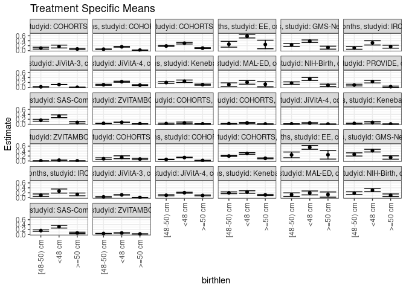

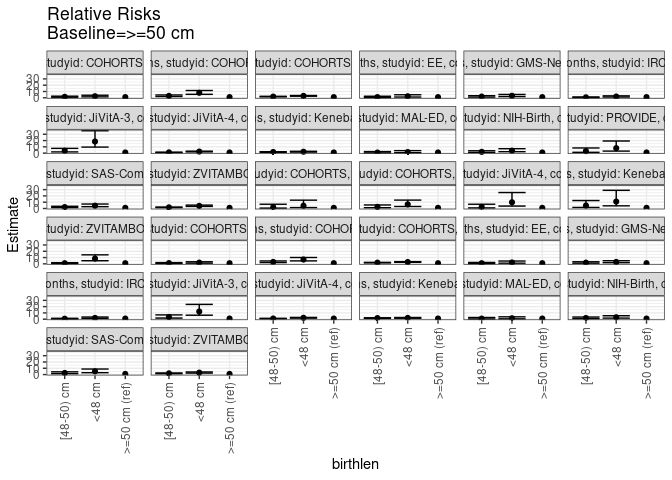

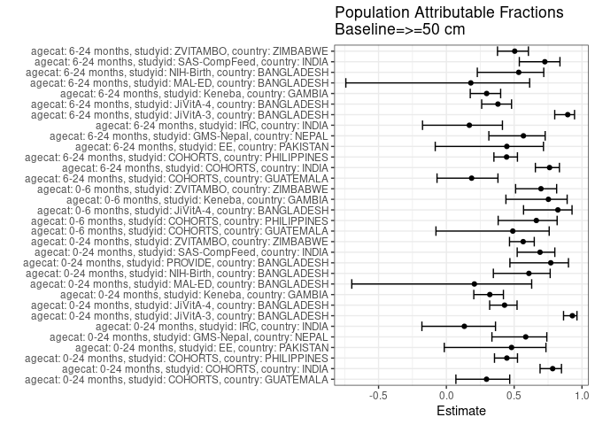

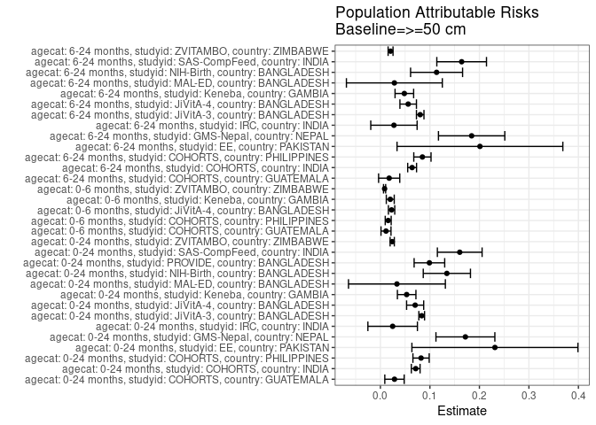

## Results Table

### Parameter: TSM

| agecat | studyid | country | intervention_level | baseline_level | estimate | ci_lower | ci_upper |
| --- | --- | --- | --- | --- | --- | --- | --- |
| 0-24 months | COHORTS | GUATEMALA | >=50 cm | NA | 0.0675991 | 0.0438278 | 0.0913703 |
| 0-24 months | COHORTS | GUATEMALA | <48 cm | NA | 0.1666667 | 0.1081499 | 0.2251834 |
| 0-24 months | COHORTS | GUATEMALA | [48-50) cm | NA | 0.1008065 | 0.0633131 | 0.1382998 |
| 0-24 months | COHORTS | INDIA | >=50 cm | NA | 0.0196629 | 0.0124512 | 0.0268746 |
| 0-24 months | COHORTS | INDIA | <48 cm | NA | 0.1561822 | 0.1426523 | 0.1697121 |
| 0-24 months | COHORTS | INDIA | [48-50) cm | NA | 0.0586546 | 0.0493266 | 0.0679827 |
| 0-24 months | COHORTS | PHILIPPINES | >=50 cm | NA | 0.1019504 | 0.0842896 | 0.1196111 |
| 0-24 months | COHORTS | PHILIPPINES | <48 cm | NA | 0.3018617 | 0.2690457 | 0.3346777 |
| 0-24 months | COHORTS | PHILIPPINES | [48-50) cm | NA | 0.1875540 | 0.1650576 | 0.2100504 |
| 0-24 months | EE | PAKISTAN | >=50 cm | NA | 0.2500000 | 0.0764015 | 0.4235985 |
| 0-24 months | EE | PAKISTAN | <48 cm | NA | 0.5889571 | 0.5132663 | 0.6646478 |
| 0-24 months | EE | PAKISTAN | [48-50) cm | NA | 0.2592593 | 0.1421330 | 0.3763855 |
| 0-24 months | GMS-Nepal | NEPAL | >=50 cm | NA | 0.1217391 | 0.0619333 | 0.1815449 |
| 0-24 months | GMS-Nepal | NEPAL | <48 cm | NA | 0.3839779 | 0.3338404 | 0.4341154 |
| 0-24 months | GMS-Nepal | NEPAL | [48-50) cm | NA | 0.2307692 | 0.1734697 | 0.2880687 |
| 0-24 months | IRC | INDIA | >=50 cm | NA | 0.1619718 | 0.1012969 | 0.2226467 |
| 0-24 months | IRC | INDIA | <48 cm | NA | 0.3153153 | 0.2287666 | 0.4018640 |
| 0-24 months | IRC | INDIA | [48-50) cm | NA | 0.1086957 | 0.0566980 | 0.1606933 |
| 0-24 months | JiVitA-3 | BANGLADESH | >=50 cm | NA | 0.0063542 | 0.0022034 | 0.0105051 |
| 0-24 months | JiVitA-3 | BANGLADESH | <48 cm | NA | 0.1173315 | 0.1117118 | 0.1229512 |
| 0-24 months | JiVitA-3 | BANGLADESH | [48-50) cm | NA | 0.0245724 | 0.0202540 | 0.0288909 |
| 0-24 months | JiVitA-4 | BANGLADESH | >=50 cm | NA | 0.0933442 | 0.0753593 | 0.1113291 |
| 0-24 months | JiVitA-4 | BANGLADESH | <48 cm | NA | 0.2309108 | 0.2101440 | 0.2516775 |
| 0-24 months | JiVitA-4 | BANGLADESH | [48-50) cm | NA | 0.1077066 | 0.0868515 | 0.1285616 |
| 0-24 months | Keneba | GAMBIA | >=50 cm | NA | 0.1125654 | 0.0901467 | 0.1349842 |
| 0-24 months | Keneba | GAMBIA | <48 cm | NA | 0.2491468 | 0.1996064 | 0.2986871 |
| 0-24 months | Keneba | GAMBIA | [48-50) cm | NA | 0.1979798 | 0.1628651 | 0.2330945 |
| 0-24 months | MAL-ED | BANGLADESH | >=50 cm | NA | 0.1282051 | 0.0230511 | 0.2333592 |
| 0-24 months | MAL-ED | BANGLADESH | <48 cm | NA | 0.2072072 | 0.1316425 | 0.2827719 |
| 0-24 months | MAL-ED | BANGLADESH | [48-50) cm | NA | 0.1139241 | 0.0437094 | 0.1841388 |

[output cut: 66 more lines]

### Parameter: E(Y)

| agecat | studyid | country | intervention_level | baseline_level | estimate | ci_lower | ci_upper |
| --- | --- | --- | --- | --- | --- | --- | --- |
| 0-24 months | COHORTS | GUATEMALA | NA | NA | 0.0960384 | 0.0760175 | 0.1160593 |
| 0-24 months | COHORTS | INDIA | NA | NA | 0.0909777 | 0.0840539 | 0.0979015 |
| 0-24 months | COHORTS | PHILIPPINES | NA | NA | 0.1840632 | 0.1702782 | 0.1978483 |
| 0-24 months | EE | PAKISTAN | NA | NA | 0.4813278 | 0.4181144 | 0.5445412 |
| 0-24 months | GMS-Nepal | NEPAL | NA | NA | 0.2934307 | 0.2593074 | 0.3275539 |
| 0-24 months | IRC | INDIA | NA | NA | 0.1867008 | 0.1480272 | 0.2253743 |
| 0-24 months | JiVitA-3 | BANGLADESH | NA | NA | 0.0897702 | 0.0855711 | 0.0939692 |
| 0-24 months | JiVitA-4 | BANGLADESH | NA | NA | 0.1635066 | 0.1508784 | 0.1761348 |
| 0-24 months | Keneba | GAMBIA | NA | NA | 0.1655928 | 0.1470936 | 0.1840919 |
| 0-24 months | MAL-ED | BANGLADESH | NA | NA | 0.1615721 | 0.1137975 | 0.2093466 |
| 0-24 months | NIH-Birth | BANGLADESH | NA | NA | 0.2205638 | 0.1874426 | 0.2536851 |
| 0-24 months | PROVIDE | BANGLADESH | NA | NA | 0.1285714 | 0.1037574 | 0.1533855 |
| 0-24 months | SAS-CompFeed | INDIA | NA | NA | 0.2320000 | 0.1911686 | 0.2728314 |
| 0-24 months | ZVITAMBO | ZIMBABWE | NA | NA | 0.0420862 | 0.0387367 | 0.0454357 |
| 0-6 months | COHORTS | GUATEMALA | NA | NA | 0.0230583 | 0.0128042 | 0.0333123 |
| 0-6 months | COHORTS | PHILIPPINES | NA | NA | 0.0237154 | 0.0183020 | 0.0291288 |
| 0-6 months | JiVitA-4 | BANGLADESH | NA | NA | 0.0274281 | 0.0217023 | 0.0331538 |
| 0-6 months | Keneba | GAMBIA | NA | NA | 0.0264346 | 0.0184482 | 0.0344210 |
| 0-6 months | ZVITAMBO | ZIMBABWE | NA | NA | 0.0120947 | 0.0102659 | 0.0139235 |
| 6-24 months | COHORTS | GUATEMALA | NA | NA | 0.0950413 | 0.0736937 | 0.1163890 |
| 6-24 months | COHORTS | INDIA | NA | NA | 0.0841713 | 0.0772407 | 0.0911019 |
| 6-24 months | COHORTS | PHILIPPINES | NA | NA | 0.1910032 | 0.1764432 | 0.2055633 |
| 6-24 months | EE | PAKISTAN | NA | NA | 0.4510638 | 0.3873080 | 0.5148197 |
| 6-24 months | GMS-Nepal | NEPAL | NA | NA | 0.3242784 | 0.2864427 | 0.3621142 |
| 6-24 months | IRC | INDIA | NA | NA | 0.1611253 | 0.1246376 | 0.1976130 |
| 6-24 months | JiVitA-3 | BANGLADESH | NA | NA | 0.0898153 | 0.0848110 | 0.0948197 |
| 6-24 months | JiVitA-4 | BANGLADESH | NA | NA | 0.1475190 | 0.1356672 | 0.1593708 |
| 6-24 months | Keneba | GAMBIA | NA | NA | 0.1627438 | 0.1439757 | 0.1815119 |
| 6-24 months | MAL-ED | BANGLADESH | NA | NA | 0.1563981 | 0.1072708 | 0.2055254 |
| 6-24 months | NIH-Birth | BANGLADESH | NA | NA | 0.2126437 | 0.1775086 | 0.2477788 |
| 6-24 months | SAS-CompFeed | INDIA | NA | NA | 0.2260174 | 0.1899444 | 0.2620905 |
| 6-24 months | ZVITAMBO | ZIMBABWE | NA | NA | 0.0406999 | 0.0369536 | 0.0444461 |

### Parameter: RR

| agecat | studyid | country | intervention_level | baseline_level | estimate | ci_lower | ci_upper |
| --- | --- | --- | --- | --- | --- | --- | --- |
| 0-24 months | COHORTS | GUATEMALA | >=50 cm | >=50 cm | 1.0000000 | 1.0000000 | 1.000000 |
| 0-24 months | COHORTS | GUATEMALA | <48 cm | >=50 cm | 2.4655172 | 1.5000244 | 4.052451 |
| 0-24 months | COHORTS | GUATEMALA | [48-50) cm | >=50 cm | 1.4912403 | 0.8938260 | 2.487953 |
| 0-24 months | COHORTS | INDIA | >=50 cm | >=50 cm | 1.0000000 | 1.0000000 | 1.000000 |
| 0-24 months | COHORTS | INDIA | <48 cm | >=50 cm | 7.9429811 | 5.4489904 | 11.578466 |
| 0-24 months | COHORTS | INDIA | [48-50) cm | >=50 cm | 2.9830071 | 2.0000468 | 4.449062 |
| 0-24 months | COHORTS | PHILIPPINES | >=50 cm | >=50 cm | 1.0000000 | 1.0000000 | 1.000000 |
| 0-24 months | COHORTS | PHILIPPINES | <48 cm | >=50 cm | 2.9608696 | 2.4132332 | 3.632781 |
| 0-24 months | COHORTS | PHILIPPINES | [48-50) cm | >=50 cm | 1.8396603 | 1.4901528 | 2.271143 |
| 0-24 months | EE | PAKISTAN | >=50 cm | >=50 cm | 1.0000000 | 1.0000000 | 1.000000 |
| 0-24 months | EE | PAKISTAN | <48 cm | >=50 cm | 2.3558282 | 1.1626544 | 4.773496 |
| 0-24 months | EE | PAKISTAN | [48-50) cm | >=50 cm | 1.0370370 | 0.4529137 | 2.374505 |
| 0-24 months | GMS-Nepal | NEPAL | >=50 cm | >=50 cm | 1.0000000 | 1.0000000 | 1.000000 |
| 0-24 months | GMS-Nepal | NEPAL | <48 cm | >=50 cm | 3.1541042 | 1.8972130 | 5.243678 |
| 0-24 months | GMS-Nepal | NEPAL | [48-50) cm | >=50 cm | 1.8956044 | 1.0931816 | 3.287026 |
| 0-24 months | IRC | INDIA | >=50 cm | >=50 cm | 1.0000000 | 1.0000000 | 1.000000 |
| 0-24 months | IRC | INDIA | <48 cm | >=50 cm | 1.9467293 | 1.2235431 | 3.097361 |
| 0-24 months | IRC | INDIA | [48-50) cm | >=50 cm | 0.6710775 | 0.3655084 | 1.232106 |
| 0-24 months | JiVitA-3 | BANGLADESH | >=50 cm | >=50 cm | 1.0000000 | 1.0000000 | 1.000000 |
| 0-24 months | JiVitA-3 | BANGLADESH | <48 cm | >=50 cm | 18.4650420 | 9.5869347 | 35.564838 |
| 0-24 months | JiVitA-3 | BANGLADESH | [48-50) cm | >=50 cm | 3.8670877 | 1.9755936 | 7.569556 |
| 0-24 months | JiVitA-4 | BANGLADESH | >=50 cm | >=50 cm | 1.0000000 | 1.0000000 | 1.000000 |
| 0-24 months | JiVitA-4 | BANGLADESH | <48 cm | >=50 cm | 2.4737570 | 2.0001034 | 3.059579 |
| 0-24 months | JiVitA-4 | BANGLADESH | [48-50) cm | >=50 cm | 1.1538654 | 0.8769731 | 1.518183 |
| 0-24 months | Keneba | GAMBIA | >=50 cm | >=50 cm | 1.0000000 | 1.0000000 | 1.000000 |
| 0-24 months | Keneba | GAMBIA | <48 cm | >=50 cm | 2.2133503 | 1.6704232 | 2.932741 |
| 0-24 months | Keneba | GAMBIA | [48-50) cm | >=50 cm | 1.7587973 | 1.3470804 | 2.296350 |
| 0-24 months | MAL-ED | BANGLADESH | >=50 cm | >=50 cm | 1.0000000 | 1.0000000 | 1.000000 |
| 0-24 months | MAL-ED | BANGLADESH | <48 cm | >=50 cm | 1.6162162 | 0.6586696 | 3.965805 |
| 0-24 months | MAL-ED | BANGLADESH | [48-50) cm | >=50 cm | 0.8886076 | 0.3185236 | 2.479011 |

[output cut: 66 more lines]

### Parameter: PAR

| agecat | studyid | country | intervention_level | baseline_level | estimate | ci_lower | ci_upper |
| --- | --- | --- | --- | --- | --- | --- | --- |
| 0-24 months | COHORTS | GUATEMALA | >=50 cm | NA | 0.0284393 | 0.0088465 | 0.0480322 |
| 0-24 months | COHORTS | INDIA | >=50 cm | NA | 0.0713147 | 0.0625057 | 0.0801238 |
| 0-24 months | COHORTS | PHILIPPINES | >=50 cm | NA | 0.0821129 | 0.0656740 | 0.0985518 |
| 0-24 months | EE | PAKISTAN | >=50 cm | NA | 0.2313278 | 0.0636075 | 0.3990481 |
| 0-24 months | GMS-Nepal | NEPAL | >=50 cm | NA | 0.1716915 | 0.1121921 | 0.2311909 |
| 0-24 months | IRC | INDIA | >=50 cm | NA | 0.0247289 | -0.0253020 | 0.0747599 |
| 0-24 months | JiVitA-3 | BANGLADESH | >=50 cm | NA | 0.0834159 | 0.0776731 | 0.0891588 |
| 0-24 months | JiVitA-4 | BANGLADESH | >=50 cm | NA | 0.0701624 | 0.0528981 | 0.0874267 |
| 0-24 months | Keneba | GAMBIA | >=50 cm | NA | 0.0530273 | 0.0343193 | 0.0717354 |
| 0-24 months | MAL-ED | BANGLADESH | >=50 cm | NA | 0.0333669 | -0.0644774 | 0.1312113 |
| 0-24 months | NIH-Birth | BANGLADESH | >=50 cm | NA | 0.1342329 | 0.0865477 | 0.1819181 |
| 0-24 months | PROVIDE | BANGLADESH | >=50 cm | NA | 0.0989856 | 0.0681034 | 0.1298678 |
| 0-24 months | SAS-CompFeed | INDIA | >=50 cm | NA | 0.1602511 | 0.1150815 | 0.2054208 |
| 0-24 months | ZVITAMBO | ZIMBABWE | >=50 cm | NA | 0.0238380 | 0.0195961 | 0.0280799 |
| 0-6 months | COHORTS | GUATEMALA | >=50 cm | NA | 0.0112935 | 0.0012027 | 0.0213844 |
| 0-6 months | COHORTS | PHILIPPINES | >=50 cm | NA | 0.0157367 | 0.0097173 | 0.0217561 |
| 0-6 months | JiVitA-4 | BANGLADESH | >=50 cm | NA | 0.0225540 | 0.0161589 | 0.0289490 |
| 0-6 months | Keneba | GAMBIA | >=50 cm | NA | 0.0198901 | 0.0118733 | 0.0279068 |
| 0-6 months | ZVITAMBO | ZIMBABWE | >=50 cm | NA | 0.0084380 | 0.0062661 | 0.0106098 |
| 6-24 months | COHORTS | GUATEMALA | >=50 cm | NA | 0.0176933 | -0.0037033 | 0.0390898 |
| 6-24 months | COHORTS | INDIA | >=50 cm | NA | 0.0640520 | 0.0551130 | 0.0729911 |
| 6-24 months | COHORTS | PHILIPPINES | >=50 cm | NA | 0.0848256 | 0.0674011 | 0.1022502 |
| 6-24 months | EE | PAKISTAN | >=50 cm | NA | 0.2010638 | 0.0335876 | 0.3685400 |
| 6-24 months | GMS-Nepal | NEPAL | >=50 cm | NA | 0.1842784 | 0.1172608 | 0.2512960 |
| 6-24 months | IRC | INDIA | >=50 cm | NA | 0.0273225 | -0.0194917 | 0.0741367 |
| 6-24 months | JiVitA-3 | BANGLADESH | >=50 cm | NA | 0.0803814 | 0.0727907 | 0.0879720 |
| 6-24 months | JiVitA-4 | BANGLADESH | >=50 cm | NA | 0.0560904 | 0.0394098 | 0.0727711 |
| 6-24 months | Keneba | GAMBIA | >=50 cm | NA | 0.0483427 | 0.0295652 | 0.0671202 |
| 6-24 months | MAL-ED | BANGLADESH | >=50 cm | NA | 0.0281930 | -0.0686879 | 0.1250739 |
| 6-24 months | NIH-Birth | BANGLADESH | >=50 cm | NA | 0.1134701 | 0.0609462 | 0.1659941 |
| 6-24 months | SAS-CompFeed | INDIA | >=50 cm | NA | 0.1641127 | 0.1139382 | 0.2142872 |
| 6-24 months | ZVITAMBO | ZIMBABWE | >=50 cm | NA | 0.0205110 | 0.0155552 | 0.0254668 |

### Parameter: PAF

| agecat | studyid | country | intervention_level | baseline_level | estimate | ci_lower | ci_upper |
| --- | --- | --- | --- | --- | --- | --- | --- |
| 0-24 months | COHORTS | GUATEMALA | >=50 cm | NA | 0.2961247 | 0.0702403 | 0.4671307 |
| 0-24 months | COHORTS | INDIA | >=50 cm | NA | 0.7838709 | 0.6909847 | 0.8488367 |
| 0-24 months | COHORTS | PHILIPPINES | >=50 cm | NA | 0.4461123 | 0.3548335 | 0.5244769 |
| 0-24 months | EE | PAKISTAN | >=50 cm | NA | 0.4806034 | -0.0155165 | 0.7343492 |
| 0-24 months | GMS-Nepal | NEPAL | >=50 cm | NA | 0.5851179 | 0.3359492 | 0.7407922 |
| 0-24 months | IRC | INDIA | >=50 cm | NA | 0.1324522 | -0.1803682 | 0.3623692 |
| 0-24 months | JiVitA-3 | BANGLADESH | >=50 cm | NA | 0.9292165 | 0.8640864 | 0.9631361 |
| 0-24 months | JiVitA-4 | BANGLADESH | >=50 cm | NA | 0.4291107 | 0.3192519 | 0.5212406 |
| 0-24 months | Keneba | GAMBIA | >=50 cm | NA | 0.3202274 | 0.2022815 | 0.4207344 |
| 0-24 months | MAL-ED | BANGLADESH | >=50 cm | NA | 0.2065142 | -0.6975195 | 0.6290943 |
| 0-24 months | NIH-Birth | BANGLADESH | >=50 cm | NA | 0.6085898 | 0.3465579 | 0.7655463 |
| 0-24 months | PROVIDE | BANGLADESH | >=50 cm | NA | 0.7698882 | 0.4684627 | 0.9003806 |
| 0-24 months | SAS-CompFeed | INDIA | >=50 cm | NA | 0.6907376 | 0.5222951 | 0.7997860 |
| 0-24 months | ZVITAMBO | ZIMBABWE | >=50 cm | NA | 0.5664095 | 0.4656771 | 0.6481516 |
| 0-6 months | COHORTS | GUATEMALA | >=50 cm | NA | 0.4897833 | -0.0767738 | 0.7582398 |
| 0-6 months | COHORTS | PHILIPPINES | >=50 cm | NA | 0.6635638 | 0.3819918 | 0.8168482 |
| 0-6 months | JiVitA-4 | BANGLADESH | >=50 cm | NA | 0.8222956 | 0.5691586 | 0.9267042 |
| 0-6 months | Keneba | GAMBIA | >=50 cm | NA | 0.7524263 | 0.4391351 | 0.8907174 |
| 0-6 months | ZVITAMBO | ZIMBABWE | >=50 cm | NA | 0.6976570 | 0.5106154 | 0.8132118 |
| 6-24 months | COHORTS | GUATEMALA | >=50 cm | NA | 0.1861638 | -0.0689164 | 0.3803731 |
| 6-24 months | COHORTS | INDIA | >=50 cm | NA | 0.7609728 | 0.6563946 | 0.8337220 |
| 6-24 months | COHORTS | PHILIPPINES | >=50 cm | NA | 0.4441057 | 0.3505480 | 0.5241858 |
| 6-24 months | EE | PAKISTAN | >=50 cm | NA | 0.4457547 | -0.0820923 | 0.7161168 |
| 6-24 months | GMS-Nepal | NEPAL | >=50 cm | NA | 0.5682723 | 0.3133392 | 0.7285576 |
| 6-24 months | IRC | INDIA | >=50 cm | NA | 0.1695730 | -0.1758274 | 0.4135117 |
| 6-24 months | JiVitA-3 | BANGLADESH | >=50 cm | NA | 0.8949627 | 0.7990587 | 0.9450942 |
| 6-24 months | JiVitA-4 | BANGLADESH | >=50 cm | NA | 0.3802251 | 0.2603910 | 0.4806432 |
| 6-24 months | Keneba | GAMBIA | >=50 cm | NA | 0.2970479 | 0.1760733 | 0.4002603 |
| 6-24 months | MAL-ED | BANGLADESH | >=50 cm | NA | 0.1802642 | -0.7414138 | 0.6141257 |
| 6-24 months | NIH-Birth | BANGLADESH | >=50 cm | NA | 0.5336163 | 0.2281792 | 0.7181810 |
| 6-24 months | SAS-CompFeed | INDIA | >=50 cm | NA | 0.7261063 | 0.5379759 | 0.8376323 |
| 6-24 months | ZVITAMBO | ZIMBABWE | >=50 cm | NA | 0.5039573 | 0.3770713 | 0.6049976 |